# The ChatGPT Shock and Public Information about AI and Work

## 5.6 Asymmetry Between Threat and Opportunity Narratives

We expect the ChatGPT shock to activate threat narratives (job loss, fear/resistance, inequality) more strongly than opportunity narratives (job creation, productivity, transformation). We construct composite indices and test this formally.

To formalise the asymmetric-activation pattern that emerges from the frame-level results, we construct two composite indices. The *threat* index aggregates the share of articles carrying any of the job-loss, fear, or inequality frames; the *opportunity* index does the same for job-creation, productivity, and transformation. Figure @ref(fig-threat-vs-opportunity) plots both indices over the sample period.

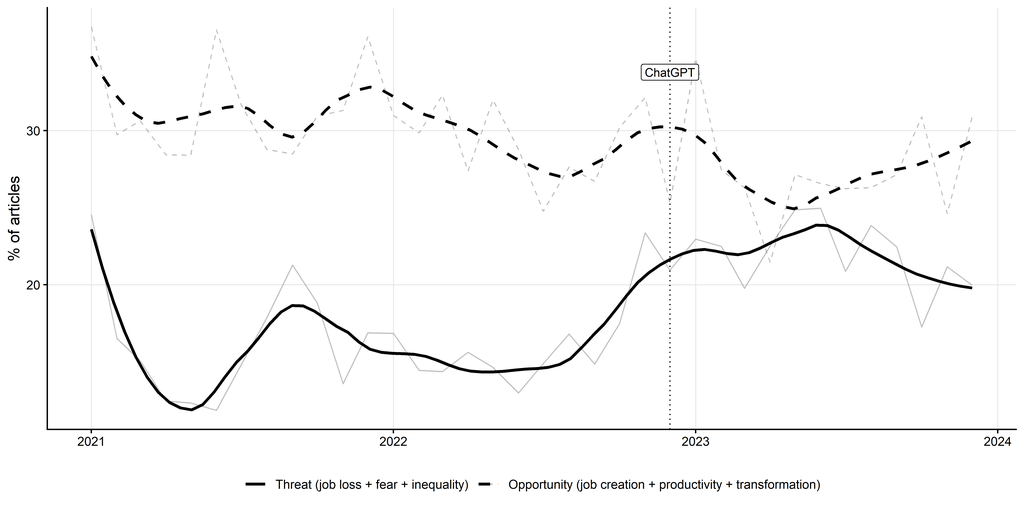

Figure 5: Composite threat and opportunity indices over time. The threat index aggregates the share of articles carrying any of the job-loss, fear, or inequality frames; the opportunity index does the same for job-creation, productivity, and transformation. Thin lines show monthly observations; thick lines are LOESS smooths.

Table @ref(tbl-asymmetry-test) tests this gap formally. We define the threat–opportunity *gap* as the difference between the two indices in each month, and regress it on a post-ChatGPT dummy with a linear time trend and HAC-robust standard errors.

Table 6: Test of asymmetric frame activation: the dependent variable is the threat–opportunity gap (in percentage points) and the post-ChatGPT coefficient measures how much the gap widens after the launch.

| Term | Estimate | SE | t_stat | p_value |
| --- | --- | --- | --- | --- |
| Intercept | -15.505 | 1.515 | -10.237 | 0.00000000000898 |
| Post ChatGPT | 6.768 | 2.047 | 3.307 | 0.00229 |
| Time trend | 0.112 | 0.101 | 1.104 | 0.27752 |

The post-ChatGPT coefficient measures how much the threat–opportunity gap widens at the launch, conditional on the linear trend. A positive and statistically significant coefficient confirms the visual asymmetry: the information environment becomes systematically more threat-oriented after the shock, and not just by a fraction of a percentage point.

## 5.7 Platform Heterogeneity

### 5.7.1 Volume by Platform

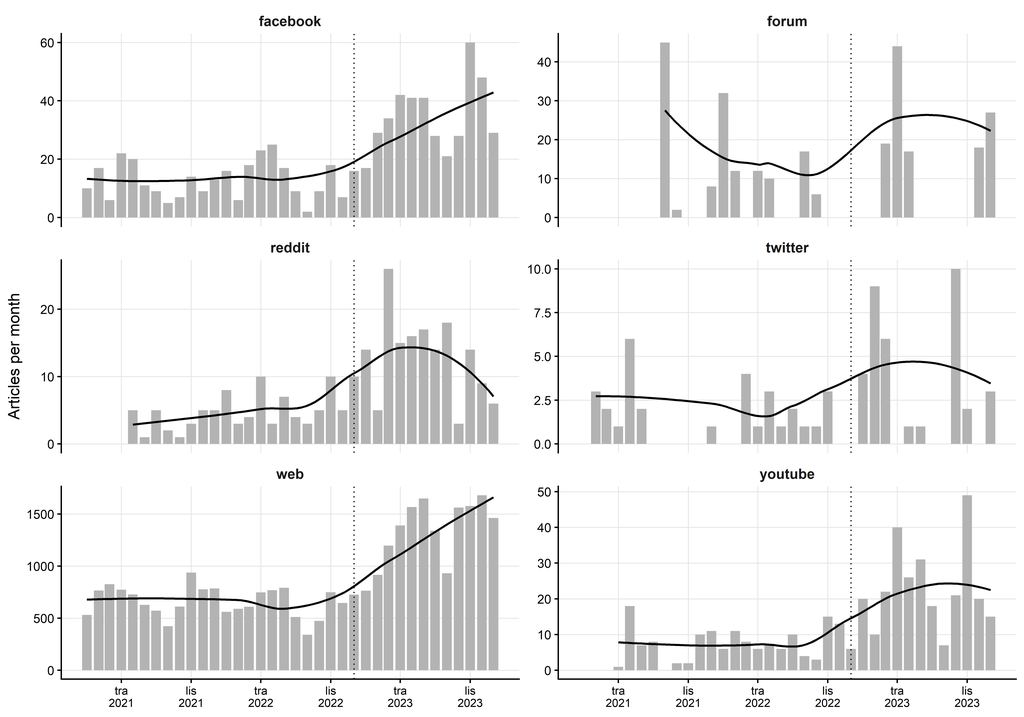

Figure 6: Monthly article volume by platform type. The dotted vertical line marks the ChatGPT launch (December 2022). The smooth line is a LOESS fit; vertical scales are platform-specific.

### 5.7.2 Platform-Specific Treatment Effects

The descriptive figure suggests heterogeneity, but the formal test in Table @ref(tbl-platform-ate) makes the magnitudes comparable. For each platform with at least 30 monthly observations, we estimate the same pre/post specification used for the aggregate volume series, with HAC-robust standard errors.

Table 7: ChatGPT treatment effect on article volume by platform. Pre- and post-monthly are average article counts before and after the launch. Ratio is post/pre. ATE is the post-dummy coefficient with HAC-robust standard error.

| Platform | Pre_monthly | Post_monthly | Ratio | ATE | SE | p_value |
| --- | --- | --- | --- | --- | --- | --- |
| youtube | 7.8 | 21.9 | 2.8 | 10.16 | 5.16 | 0.059 |
| reddit | 4.7 | 12.8 | 2.7 | 7.53 | 2.48 | 0.005 |
| facebook | 12.7 | 33.4 | 2.6 | 16.71 | 6.60 | 0.016 |
| twitter | 2.2 | 4.5 | 2.0 | 3.50 | 1.48 | 0.029 |
| web | 659.2 | 1289.7 | 2.0 | 526.98 | 196.41 | 0.011 |
| forum | 16.0 | 25.0 | 1.6 | 25.28 | 8.92 | 0.016 |

The platform-level ATEs confirm that the shock did not arrive evenly across the digital ecosystem. Web portals show the largest absolute increase in article volume; relative to baseline, several smaller platforms show even larger ratios. Where standard errors permit conclusions, the post-ChatGPT coefficient is positive on every active platform. The ranking is consistent with the view that web portals carried the heaviest load of post-shock coverage in absolute terms while social and short-form video platforms amplified the relative jump.

## 5.8 Outlet-Type Heterogeneity

A second cut at heterogeneity asks whether different *kinds* of outlets respond differently to the same shock. We use a difference-in-differences design comparing tabloid outlets (high baseline propensity for sensationalism) against quality outlets as the control group, with the threat frame (job loss + fear + inequality) as the outcome at the article level. The identifying assumption is that, absent the ChatGPT shock, tabloid and quality outlets would have followed parallel trends in threat-frame usage. Time fixed effects at the year-month level absorb common shocks. The coefficient of interest is the post × tabloid interaction, which captures the differential response of tabloids relative to quality outlets.

Table 8: Difference-in-differences estimates: threat frame (job loss + fear + inequality) as the outcome, tabloid outlets as the treatment group, quality outlets as the control. The model includes year-month fixed effects; standard errors are heteroskedasticity-robust.

| Term | Estimate | SE | t_stat | p_value |
| --- | --- | --- | --- | --- |
| Tabloid | 0.0156 | 0.0178 | 0.87 | 0.3826 |
| Post-ChatGPT × Tabloid | -0.0565 | 0.0247 | -2.28 | 0.0224 |

## 5.9 Persistence and Decay

A first-order question for any event-study finding is whether the post-shock elevation persists or whether it fades back toward the pre-shock baseline as the news cycle moves on. Mean reversion would suggest novelty-driven coverage that wears off. Persistence would suggest a more durable change in how the topic is discussed. Figure @ref(fig-persistence) plots three-month rolling averages of the threat and opportunity composite indices, smoothing out month-to-month noise to make the medium-term trajectory visible.

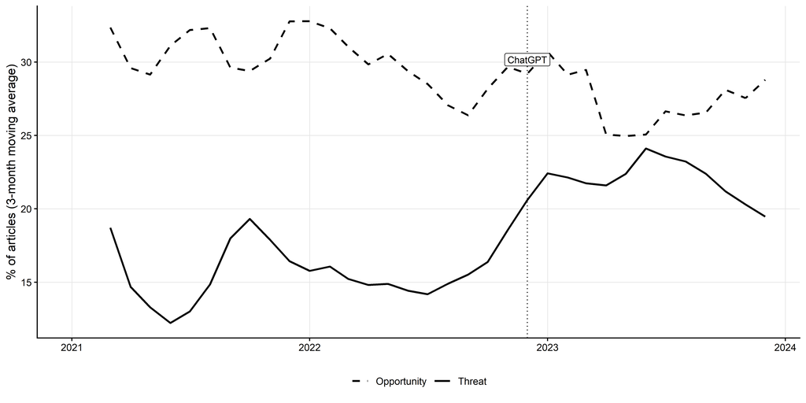

Figure 7: Three-month rolling averages of the threat and opportunity composite indices. The dotted vertical line marks the ChatGPT launch.

### 5.9.1 Post-Shock Decay Estimation

A more formal test of persistence regresses each frame’s post-shock share on months since the shock. A negative and significant slope would indicate gradual decay back toward baseline; a positive or insignificant slope would indicate continuing growth or a stable plateau.

Table 9: Post-shock decay estimation. For each frame, we regress monthly post-ChatGPT share on months since the launch. A negative significant slope (“Decaying”) would indicate fade-out; a positive significant slope (“Growing”) indicates continued increase; otherwise the post-shock level is stable.

| Frame | Initial_level | Monthly_decay | p_value | Pattern |
| --- | --- | --- | --- | --- |
| JOB_LOSS | 2.73 | -0.004 | 0.919 | Stable (no sig. trend) |
| JOB_CREATION | 3.54 | 0.084 | 0.214 | Stable (no sig. trend) |
| TRANSFORMATION | 5.03 | 0.043 | 0.576 | Stable (no sig. trend) |
| SKILLS | 5.47 | 0.042 | 0.558 | Stable (no sig. trend) |
| REGULATION | 4.05 | 0.145 | 0.177 | Stable (no sig. trend) |
| PRODUCTIVITY | 21.71 | -0.005 | 0.983 | Stable (no sig. trend) |
| INEQUALITY | 2.09 | -0.022 | 0.722 | Stable (no sig. trend) |
| FEAR_RESISTANCE | 19.56 | -0.052 | 0.760 | Stable (no sig. trend) |

# 6 Robustness

## 6.1 Alternative Event Windows

The pre/post estimates pool all available months on either side of the launch. A natural concern is that the result depends on this choice. We re-estimate the threat-frame ATE on progressively narrower symmetric windows around the shock — six months on each side, then nine, twelve, fifteen, and eighteen — to see whether the magnitude is stable as we approach the discontinuity.

Table 10: Sensitivity of the threat-frame ATE to the choice of event window. Each row uses a symmetric window of the indicated width around the ChatGPT date.

| Window_months | ATE | SE | p |
| --- | --- | --- | --- |
| ±6 | 0.64 | 3.41 | 0.855 |
| ±9 | 2.91 | 2.78 | 0.312 |
| ±12 | 5.91 | 3.07 | 0.067 |
| ±15 | 6.15 | 2.73 | 0.034 |
| ±18 | 5.26 | 2.52 | 0.046 |

## 6.2 Poisson Count Model

Monthly article counts are non-negative integers, so OLS is technically inappropriate even though it is convenient. As a check, we re-estimate the volume specification as a quasi-Poisson regression. Quasi-Poisson allows for overdispersion (variance larger than the mean), which is common in count data with extra-Poisson volatility, and is therefore a more appropriate match for monthly article counts than a strict Poisson model. The dispersion parameter is reported alongside the regression coefficients.

Table 11: Quasi-Poisson regression of monthly article counts on a post-ChatGPT dummy and a linear time trend. IRR is the incidence rate ratio (exp(coefficient)). The dispersion parameter is reported in the bottom row; values much greater than one indicate overdispersion relative to a strict Poisson model.

| term | estimate | std.error | statistic | p.value | IRR |
| --- | --- | --- | --- | --- | --- |
| (Intercept) | 6.443 | 0.104 | 61.831 | < 0.0000000000000002 | 628.56 |
| post | 0.535 | 0.157 | 3.409 | 0.00174 | 1.71 |
| t | 0.008 | 0.007 | 1.106 | 0.27657 | 1.01 |
| Dispersion parameter | 54.600 | NA | NA | NA | NA |

## 6.3 Placebo Test

Table 12: Placebo test at December 2021 (one year before the actual ChatGPT launch). Estimation is restricted to months strictly before the actual shock so that the placebo dummy is not contaminated by the true treatment.

| Term | Estimate | SE | p_value |
| --- | --- | --- | --- |
| Intercept | 738.83 | 56.18 | 0.0000000000265 |
| Placebo post | 4.35 | 91.57 | 0.963 |
| Time trend | -4.23 | 7.01 | 0.553 |

The placebo coefficient is small and far from statistical significance. The real ChatGPT effect, by contrast, is large and precise. The contrast is the expected pattern under a clean event-study identification: the actual launch date carries information that the placebo date does not.

# 7 Discussion

Three extensions stand out. Linking the framing series to monthly Croatian Employment Service (HZZ) vacancy and registered-unemployment data at the occupational level would convert supply-side measurement into direct estimation of how the information environment co-moves with labour-market behaviour. Replicating the design on Slovenian, Serbian, and Bosnian press would test whether the asymmetric-activation pattern is specific to Croatia or broader across the region, and would also widen the scope of the analysis beyond Croatian-language media. An occupation-level extension mapping which jobs draw the most post-shock narrative attention against task-level AI exposure indices would address whether coverage tracks occupational risk or systematically misdirects worker attention.

# 8 Technical Appendix

## References

Acemoglu, Daron, and Pascual Restrepo. 2018. “The Race Between Man and Machine: Implications of Technology for Growth, Factor Shares, and Employment.” *American Economic Review* 108 (6): 1488–542.

Autor, David H. 2015. “Why Are There Still so Many Jobs? The History and Future of Workplace Automation.” *Journal of Economic Perspectives* 29 (3): 3–30.

Autor, David H. 2022. *The Labor Market Impacts of Technological Change: From Unbridled Enthusiasm to Qualified Optimism to Vast Uncertainty*. Working Paper No. 30074. National Bureau of Economic Research. https://doi.org/10.3386/w30074.

Bernal, James Lopez, Steven Cummins, and Antonio Gasparrini. 2017. “Interrupted Time Series Regression for the Evaluation of Public Health Interventions: A Tutorial.” *International Journal of Epidemiology* 46 (1): 348–55. https://doi.org/10.1093/ije/dyw098.

Bessen, James E. 2019. “Automation and Jobs: When Technology Boosts Employment.” *Economic Policy* 34 (100): 589–626.

Brynjolfsson, Erik, Danielle Li, and Lindsey R. Raymond. 2023. “Generative AI at Work.” *NBER Working Paper*, no. 31161.

Eloundou, Tyna, Sam Manning, Pamela Mishkin, and Daniel Rock. 2023. “GPTs are GPTs: An Early Look at the Labor Market Impact Potential of Large Language Models.” *arXiv Preprint arXiv:2303.10130*.

Felten, Edward W., Manav Raj, and Robert Seamans. 2021. “Occupational, Industry, and Geographic Exposure to Artificial Intelligence: A Novel Dataset and Its Potential Uses.” *Strategic Management Journal* 42 (12): 2195–217.